# index

## Canada’s National Inventory Report

Each year, Canada and all other signatories to the United Nations Framework Convention on Climate Change submit [annual National Inventory Reports (NIRs)](https://unfccc.int/ghg-inventories-annex-i-parties/2021) which track annual GHG emissions within their countries.

These graphs use [Canada’s emissions inventory](https://www.canada.ca/en/environment-climate-change/services/climate-change/greenhouse-gas-emissions/inventory.html), combined with [emissions projections](https://www.canada.ca/en/environment-climate-change/services/climate-change/greenhouse-gas-emissions/projections.html) from Environment and Climate Change Canada, to help frame both our emissions past and future.

Canada has a long road ahead, especially with the new Glasgow target to reduce emissions to 40-45% below 2005 levels by 2030, but projections over time show that we are bending the emissions curve with policies and new technology.

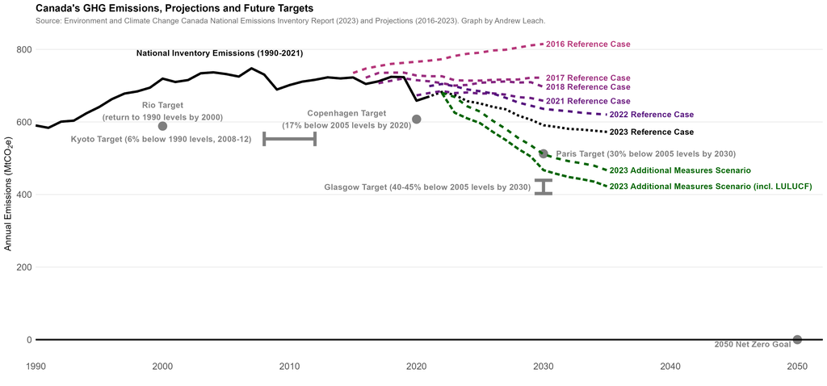

Canada’s emissions inventory by province shows where emissions have increased and why different provinces may feel more of a threat from climate change policies.

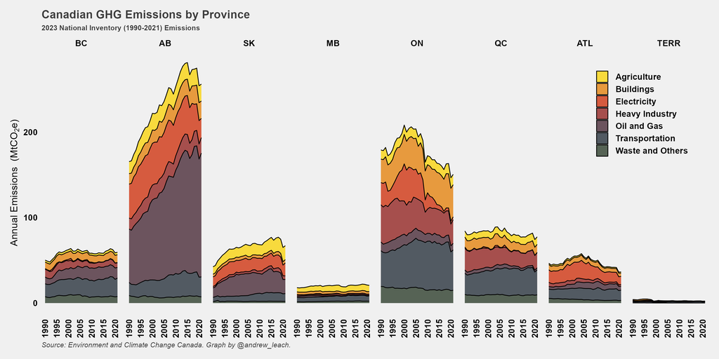

Slicing Canada’s emissions inventory by economic sector and province shows a surprising picture in some ways, but also captures where our policy focus really needs to be if we’re going to materially reduce emissions: oil and gas and transportation.

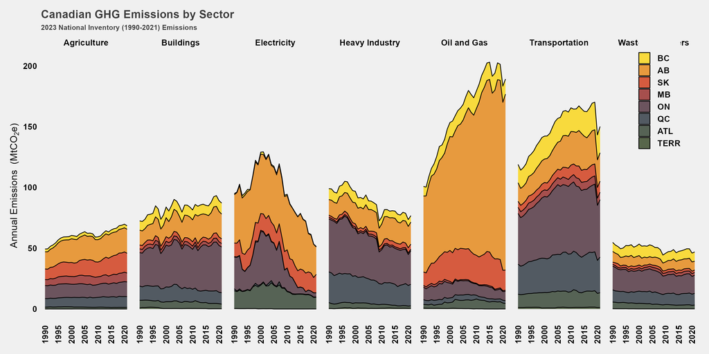

Canada’s emissions inventory by province shown on a per-capita basis is particularly striking.

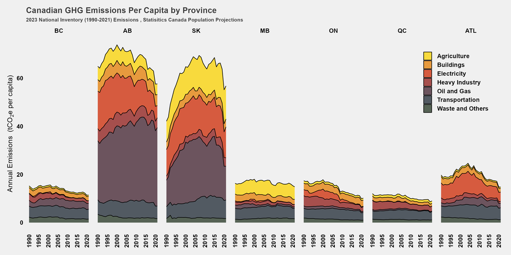